[figure not shown]

# Ireland Dodgeball History

Dr. Blain Murphy

# Introduction

Ireland’s international dodgeball programme has evolved dramatically since its first appearance in 2011. The dataset underpinning this report captures the full competitive history of every player who has represented Ireland across Euros, Worlds, Nations Cup, and NEC tournaments. It includes **120 capped players**, spanning **15 years**, with detailed information on:

- Debut year
- Number of tournaments played
- Tournament-by-tournament participation
- Leadership roles (captains)
- Squad sizes and event formats
- Geographic distribution of tournaments
- Match volumes and placements

This rich dataset allows us to trace the **development, continuity, and renewal** of the Irish dodgeball programme. By combining participation records, debut cohorts, squad composition, and tournament outcomes, we can build a clear picture of how the national team has grown, who its key contributors have been, and how Ireland’s competitive footprint has expanded across Europe and the world.

# Key points

### **2. A Strong Core of Experienced Players**

A small group of athletes have accumulated **10+ tournaments**, forming the backbone of the squad for over a decade. Players like Garvan McEvoy, Meg Shine, Rob Kearns, Cat Hall, and others appear consistently across multiple formats and eras.

### **3. Programme Growth and Stability**

Heatmaps reveal a stable core of long‑term contributors, supported by a steady influx of new players. Even after the COVID disruption (2020–21), the programme rebounded strongly with a large 2022 cohort.

### **4. Leadership Continuity**

The captains’ wordcloud shows leadership concentrated among a small, trusted group. This continuity supports team culture, performance, and the integration of new players.

### **5. Expanding International Footprint**

The Euros locations map illustrates Ireland’s participation across a wide geographic range — from central Europe to Scandinavia — reflecting the increasing professionalism and reach of the sport.

### **7. Competitive Performance Over Time**

# **Why This Matters**

Together, these insights provide a comprehensive view of Ireland’s dodgeball journey — from its early foundations to its modern, multi‑format national programme. The data not only celebrates the contributions of every capped player but also reveals the structural patterns that shape performance, development, and long‑term success.

# Debuts

Your dataset includes **120 capped players** from 2011–2025. When you look at debut years, a few patterns jump out immediately:

## **1. Major “waves” of new players**

Certain years produced unusually large debut cohorts:

[output not shown]

- Ireland’s dodgeball programme grows in **cycles**, not gradually.
- Big debut years align with:
  - Euros expansion years
  - Worlds cycles
  - Post‑COVID restart
  - Organisational growth (e.g., 2022–2024 boom)
- Many debutants go on to become **long‑term contributors** (e.g., Garvan McEvoy, Meg Shine, Blain Murphy).
- Others appear for **1–3 tournaments**, often filling specific squad needs.
- The 2022–2024 cohorts show **high retention**, with many players appearing in multiple formats.

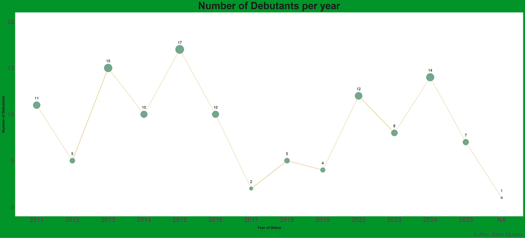

Figure 1. Annual Number of Ireland Dodgeball Debutants

# Squad Size by Tournament

## **2. Worlds squads are smaller and more selective**

Worlds squads typically include:

- **Mens**
- **Womens**
- **Mixed**
- Sometimes foam divisions (2022, 2024)

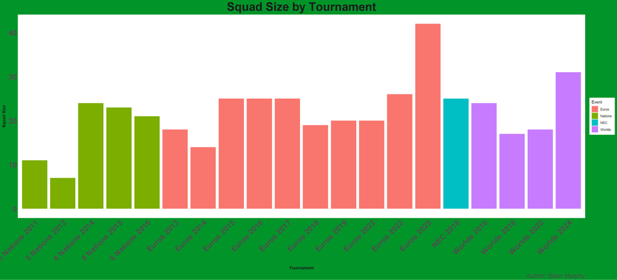

Figure 2. Squad Size by Tournament

# Participation Heatmaps over multiple tournaments

- A core group of players show **long-term continuity**, appearing across many years.
- Newer players gradually move into the mid‑experience band, showing **strong retention**.
- The heatmap reveals **clusters of consistent participation**, indicating stable leadership and reliable squad members.
- You can see **generational cohorts** entering together.
- Some debut groups stay active for many years, while others taper off quickly.
- The programme shows **steady renewal**, with new cohorts appearing every few years.

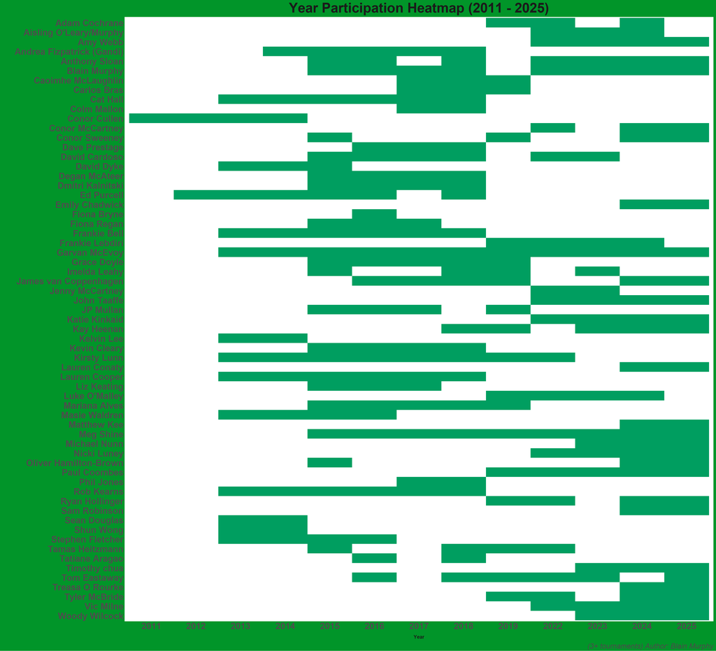

Figure 3. Player Participation Heatmap (3+ Tournaments)

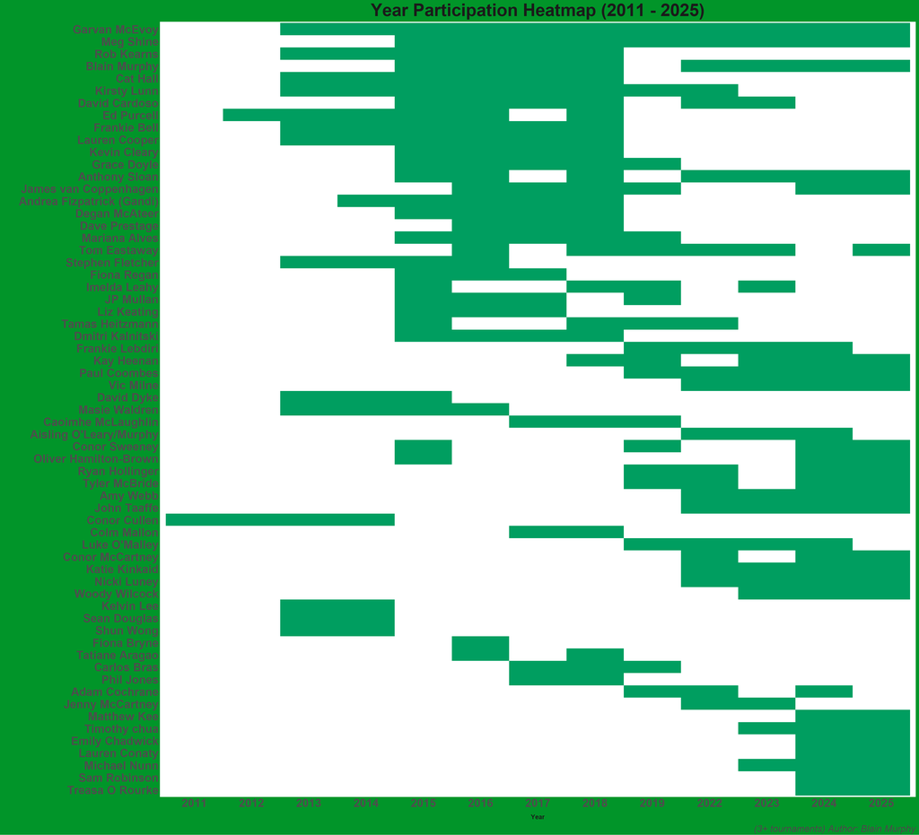

Figure 4. Participation Heatmap Ordered by Total Appearances

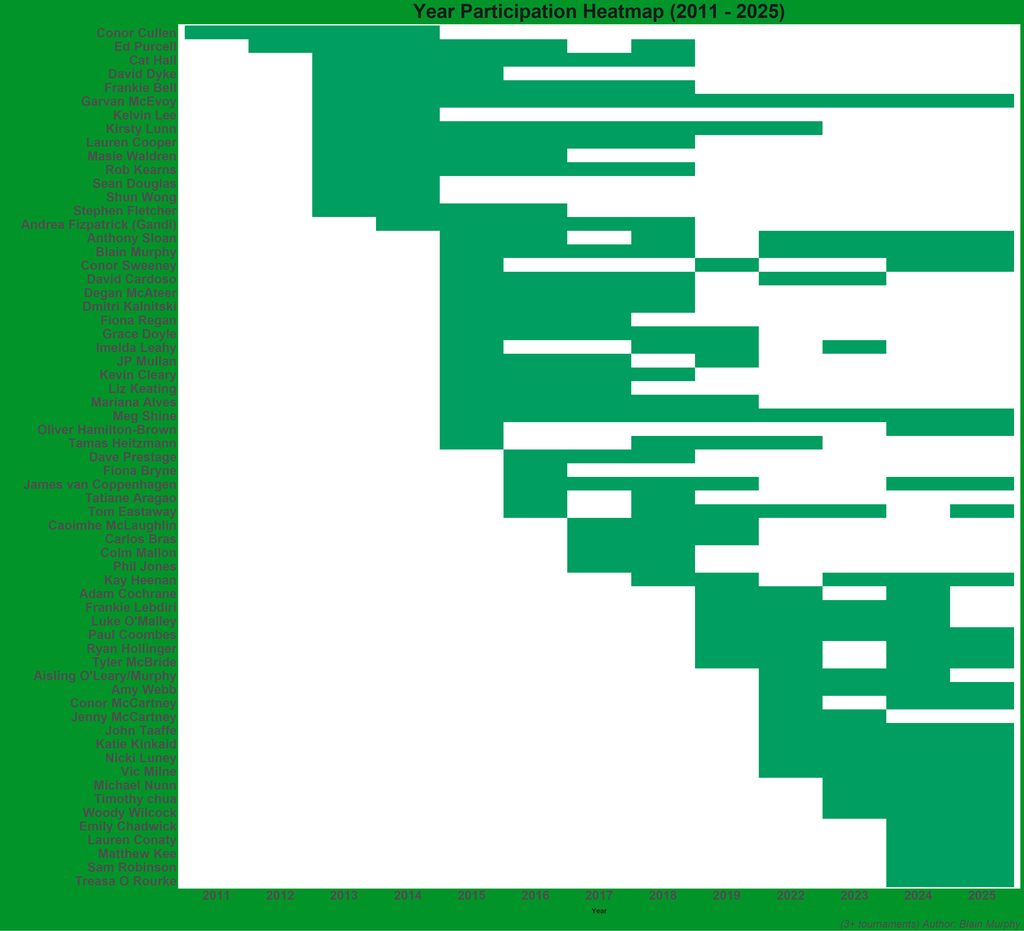

Figure 5. Participation Heatmap Ordered by Debut Year

# Locations of Events

- Ireland has competed across a wide geographic spread of European host cities.
- The distribution shows:
  - Western and Central Europe dominate hosting.
  - Travel demands vary significantly year‑to‑year.

This highlights the logistical complexity of international dodgeball and the adaptability of the Irish squad.

[interactive chart not shown]

Figure 6. Geographic Distribution of European Dodgeball Events

[interactive chart not shown]

Figure 6. Geographic Distribution of World Dodgeball Events

# Wordclouds

- The largest names represent players with the **highest number of tournaments**.
- The cloud visually reinforces:
  - Who the long‑term contributors are.
  - The depth of experience in the programme.

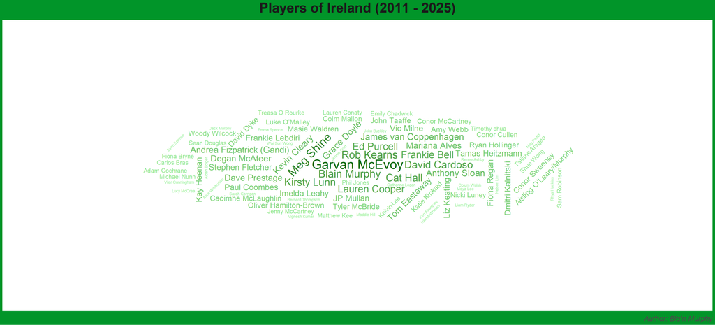

Figure 7. Wordcloud of Ireland Dodgeball Players (2011–2025)

- Leadership is concentrated among a **small group of recurring captains**.
- Some captains have led across many tournaments, indicating:
  - Trust from coaching staff
  - Strong leadership continuity
  - Stability in team culture

### **Interpretation**

Leadership within the Ireland squad is consistent and anchored by a few key individuals.

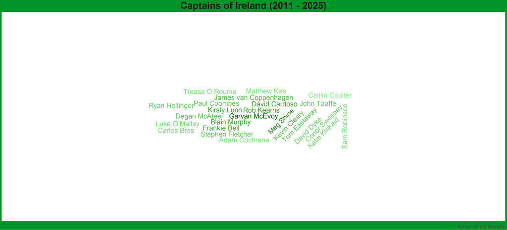

Figure 8. Wordcloud of Ireland Dodgeball Captains

# **Final Synopsis**

Across fifteen years of international competition, the Ireland Dodgeball programme has demonstrated clear growth, resilience, and strategic evolution. The underlying data reveals a national team shaped by distinct waves of new talent, a stable core of long‑term contributors, and a leadership group that has anchored the squad through multiple competitive cycles.

Participation heatmaps highlight the balance between renewal and stability. A strong core of players appears across many years, while new cohorts integrate steadily into the system. Ordering by caps, debut year, and full participation reveals a programme that has matured from early experimentation into a structured, multi‑format national pathway.

Leadership patterns, captured through the captains’ wordcloud, show that responsibility has been concentrated among a trusted group of experienced athletes. This continuity has supported team culture, performance consistency, and the integration of younger players.

Geographically, Ireland’s competitive footprint has expanded significantly, with participation across a wide range of European host cities and increasing involvement in global events. This reflects both the sport’s growth and Ireland’s rising ambition on the international stage.

Taken together, the data paints a picture of a programme that is **bigger, deeper, and more strategically organised than at any point in its history**. Ireland now fields larger squads, competes in more formats, and develops players through clearer pathways than ever before. The recent surge in debutants, combined with a strong veteran core, positions the team well for the next phase of international competition.

This report not only documents the past but also highlights the foundations of future success: sustained recruitment, experienced leadership, and a growing competitive presence across Europe and the world.

Acknowledgements: Thank you to the members of the Irish Dodgeball Association who assisted in the data finding for this report.